# **PCFL 2023: Week 6 wrap-up**

Week 6 is a wrap!

The bye weeks have arrived y’all. Check your lineups!!

## Last week’s games

| Winner | Winner’s score | Loser | Loser’s score |
| --- | --- | --- | --- |
| Georgia Peanuts | 120.16 | Captain Clairvoyant | 93.64 |
| Southern Sharks | 115.12 | Pigskin on the Gridiron | 61.12 |
| The G.O.A.T. | 96.01 | KC Gophers | 70.04 |
| Athens Team Sasquatch | 142.70 | Middle Earth Hangry Hobbits | 126.72 |
| Jumpin’ Jaheims | 91.48 | The Seniors | 74.10 |

Hangry Hobbits has the tough luck loss, while Jumpin’ Jaheims had a lucky win.

## Best performances

### Best players overall

Here’s last week’s **10 best performing starters.**

| Player | Position | NFL Team | Points | PCFL Team |
| --- | --- | --- | --- | --- |
| Raheem Mostert | RB | MIA | 32.70 | Middle Earth Hangry Hobbits |
| Tyreek Hill | WR | MIA | 26.30 | Athens Team Sasquatch |
| Amon-Ra St. Brown | WR | DET | 24.40 | Southern Sharks |
| Cooper Kupp | RB/WR/TE | LAR | 24.30 | The G.O.A.T. |
| Adam Thielen | RB/WR/TE | CAR | 23.00 | Georgia Peanuts |
| Jared Goff | QB | DET | 22.42 | Southern Sharks |
| Travis Etienne Jr. | RB | JAC | 21.80 | Athens Team Sasquatch |
| Kyren Williams | RB/WR/TE | LAR | 21.80 | Athens Team Sasquatch |
| Jalen Hurts | QB | PHI | 19.90 | The Seniors |
| Justin Tucker | K | BAL | 19.00 | Athens Team Sasquatch |

Rahemm Mostert leading the pack, and Adam Thielen among top performaners. Who knew?

### Best players per team

Here’s last week’s top players **on each team.**

| Player | Position | NFL Team | Points | PCFL Team |
| --- | --- | --- | --- | --- |
| Tyreek Hill | WR | MIA | 26.30 | Athens Team Sasquatch |
| Travis Kelce | TE | KCC | 16.90 | Captain Clairvoyant |
| Adam Thielen | RB/WR/TE | CAR | 23.00 | Georgia Peanuts |
| Justin Herbert | QB | LAC | 18.58 | Jumpin’ Jaheims |
| Patrick Mahomes | QB | KCC | 17.34 | KC Gophers |
| Raheem Mostert | RB | MIA | 32.70 | Middle Earth Hangry Hobbits |
| Dak Prescott | BE | DAL | 24.88 | Pigskin on the Gridiron |
| Amon-Ra St. Brown | WR | DET | 24.40 | Southern Sharks |
| Cooper Kupp | RB/WR/TE | LAR | 24.30 | The G.O.A.T. |
| Jalen Hurts | QB | PHI | 19.90 | The Seniors |

### Best bench

Who won the **best scoring bench** award last week?

| Team | Bench points |
| --- | --- |
| Pigskin on the Gridiron | 68.28 |
| Middle Earth Hangry Hobbits | 62.30 |
| Jumpin’ Jaheims | 57.00 |
| Athens Team Sasquatch | 54.64 |
| KC Gophers | 51.60 |
| Southern Sharks | 44.90 |
| Captain Clairvoyant | 38.30 |
| Georgia Peanuts | 35.24 |
| The G.O.A.T. | 34.90 |
| The Seniors | 28.94 |

Here’s the season’s bench standings:

| Team | Bench points |
| --- | --- |
| Georgia Peanuts | 425.18 |
| Athens Team Sasquatch | 385.38 |
| Southern Sharks | 372.60 |
| The Seniors | 336.11 |
| Pigskin on the Gridiron | 331.27 |
| Jumpin’ Jaheims | 327.00 |
| Middle Earth Hangry Hobbits | 321.82 |
| Captain Clairvoyant | 309.82 |
| KC Gophers | 303.80 |
| The G.O.A.T. | 243.34 |

Not to brag, but I’ve got a sizable lead built up here.

### Best optimized lineups

I compared the actual starting lineups for each team to the hypothetical *best* starting lineup the owner could have started. The table below shows the actual points the team scored, the top score they could have had, and an “optimization” percentage that compares to the two.

| PCFL Team | Actual points | Best lineup | Optimization rate |
| --- | --- | --- | --- |
| Georgia Peanuts | 120.16 | 120.16 | 100% |
| Athens Team Sasquatch | 142.70 | 148.10 | 96% |
| The G.O.A.T. | 96.01 | 99.61 | 96% |
| Middle Earth Hangry Hobbits | 126.72 | 139.08 | 91% |
| Jumpin’ Jaheims | 91.48 | 101.48 | 90% |
| Captain Clairvoyant | 93.64 | 104.64 | 89% |
| The Seniors | 74.10 | 83.30 | 89% |
| Southern Sharks | 115.12 | 134.52 | 86% |
| KC Gophers | 70.04 | 93.54 | 75% |
| Pigskin on the Gridiron | 61.12 | 104.38 | 59% |

For the *whole season*, here’s a graph of actual points scored vs. optimized points given the roster.

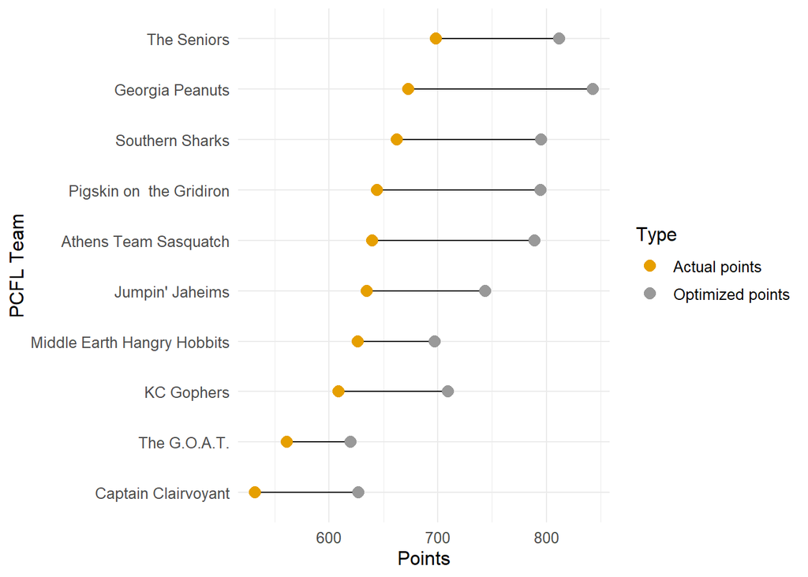

If only I knew how to maximize my lineup.

### Point distribution by position

**NEW THIS WEEK!** Here’s a breakdown of point contribution by position by team so far this season. For example, The GOAT has something like 25% of his points from QB, while Team Sasquatch is more like 10%. More on this as we go forward.

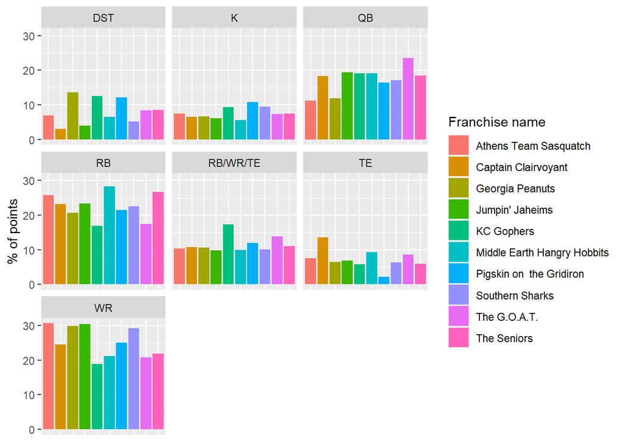

```r
ggplot(starters_pct,aes(y=points_pct,
                        x=franchise_name,
                        fill=franchise_name))+
  geom_bar(stat='identity')+
  ylab("% of points")+xlab("")+
  facet_wrap(~lineup_slot)+
  theme(axis.title.x=element_blank(),
        axis.text.x=element_blank(),
        axis.ticks.x=element_blank())+
   labs(fill = "Franchise name")
```

### Best pick-ups

There were 9 players added last week. Which was the **best pick-ups**?

| PCFL Team | Player | NFL Team | Position | Points |
| --- | --- | --- | --- | --- |
| Athens Team Sasquatch | Chiefs D/ST | KCC | DST | 16.0 |
| Middle Earth Hangry Hobbits | Chuba Hubbard | CAR | RB | 15.5 |
| Middle Earth Hangry Hobbits | Jordan Addison | MIN | WR | 10.3 |
| Middle Earth Hangry Hobbits | Falcons D/ST | ATL | DST | 8.0 |
| Southern Sharks | Joshua Palmer | LAC | WR | 8.0 |
| Georgia Peanuts | D’Onta Foreman | CHI | RB | 7.2 |
| Southern Sharks | K.J. Osborn | MIN | WR | 6.8 |
| Captain Clairvoyant | 49ers D/ST | SFO | DST | 6.0 |
| The Juniors | Emari Demercado | ARI | RB | NA |

The Hobbits made some good moves last week.

### Best team performances

Here’s a list of the **top five scoring performances** so far this season.

| PCFL Team | Week | Score | Result |
| --- | --- | --- | --- |
| Middle Earth Hangry Hobbits | 2 | 167.18 | W |
| Jumpin’ Jaheims | 4 | 149.98 | W |
| Georgia Peanuts | 4 | 148.64 | W |
| The Seniors | 3 | 146.88 | W |
| Athens Team Sasquatch | 6 | 142.70 | W |

Scott still hanging tight at the top.

## Looking ahead

### League standings

| PCFL Team | Division | Points scored | Avg points | Avg last 3 | W | L | Team points |
| --- | --- | --- | --- | --- | --- | --- | --- |
| The Seniors | Hot Dish | 698.13 | 116.36 | 102.24 | 3 | 3 | 8 |
| Southern Sharks | Hot Dish | 662.16 | 110.36 | 99.88 | 3 | 3 | 8 |
| Georgia Peanuts | Hot Dish | 672.86 | 112.14 | 131.63 | 3 | 3 | 7 |
| Pigskin on the Gridiron | Grits | 644.00 | 107.33 | 89.43 | 4 | 2 | 7 |
| Athens Team Sasquatch | Grits | 639.58 | 106.60 | 117.35 | 4 | 2 | 7 |
| KC Gophers | Hot Dish | 608.52 | 101.42 | 90.97 | 3 | 3 | 6 |
| Jumpin’ Jaheims | Grits | 634.66 | 105.78 | 115.73 | 3 | 3 | 5 |
| Middle Earth Hangry Hobbits | Hot Dish | 626.60 | 104.43 | 88.86 | 2 | 4 | 5 |
| The G.O.A.T. | Grits | 561.29 | 93.55 | 105.82 | 3 | 3 | 5 |
| Captain Clairvoyant | Grits | 531.54 | 88.59 | 95.30 | 2 | 4 | 2 |

A lot of parity at the top, but right now, the Stertz sisters are 1 and 2.

### If the season ended today…

Seniors and Sharks are in, with Peanuts and Pigskin as the last two. Team Sasquatch barely loses by points in a tiebreaker.

### Next week’s matchups

| Team 1 | Team 2 |
| --- | --- |
| Athens Team Sasquatch (Avg. last 3: 117.35) | The Seniors (Avg. last 3: 102.24) |
| Captain Clairvoyant (Avg. last 3: 95.3) | KC Gophers (Avg. last 3: 90.97) |
| Georgia Peanuts (Avg. last 3: 131.63) | Pigskin on the Gridiron (Avg. last 3: 89.43) |
| Jumpin’ Jaheims (Avg. last 3: 115.73) | Southern Sharks (Avg. last 3: 99.88) |
| Middle Earth Hangry Hobbits (Avg. last 3: 88.86) | The G.O.A.T. (Avg. last 3: 105.82) |

Good luck, y’all!